# R als Programmiersprache

Dirk Seidensticker/Clemens Schmid

Februar 2016

## Grundlagen

#### Grundlagen

[figure not shown]

R Logo

- R ist eine **vollwertige Programmiersprache** zur statistischen **Datenverarbeitung und -visualisierung**
  - Eigene Paradigmen, Syntax, Datenstrukturen/formate, Klassen (Objektorienterung), Konventionen, Normendiskussion, Weiterentwicklung…
- R ist **quelloffen** (unter GNU GPL) läuft unter diversen **UNIX-**, **Linux-** und Unix-ähnlichen Betriebsystemen, sowie auf **Windows** und **Mac OS X**
- Eine große Anzahl von existierenden Zusatzpaketen (**libraries**) aus Community-Entwicklung ergänzen die R-Funktionalität - **eigene Funktionen** können unmittelbar entworfen und implementiert werden
- R kann mit anderen Programmiersprachen wie **Python**, **C**, **Ruby**, **Fortran** und **JavaScript** etc. verbunden werden

#### Grundlagen

- R ist eine **Interpretersprache**, die nicht kompiliert werden muss
  - R muss installiert sein, um ein Skript ausführen zu können
  - Mit dem Paket `compiler` können Funktionen zu Byte-Code kompiliert werden
- R ist **langsam** (Primzahlbeispiel R-Bloggers: Python*17, C*270)
- R hält Arbeitsdaten im **Hauptspeicher** vor
- Es gibt mehrere GUIs und IDEs für R: R auf CMD und Bash, **R GUI**, R commander, **RStudio**, …

> „To understand computations in R, two slogans are helpful: **Everything that exists is an object. Everything that happens is a function call.**“ - John Chambers 2014

## Geschichte

#### Geschichte - S

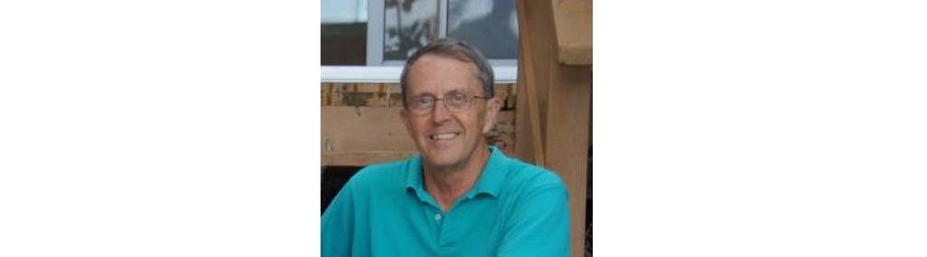

John Chambers

- *1969:* **John Chambers** (Bell Laboratories) veröffentlicht den ersten Entwurf einer statistischen Sprache (Chambers 1969): Geburtsstunde von **S**
- *1975-1976/1980/1988:* Entwicklung von S1, S2 und schließlich S3 (kommerzielle Variante S-PLUS)

#### Geschichte - R

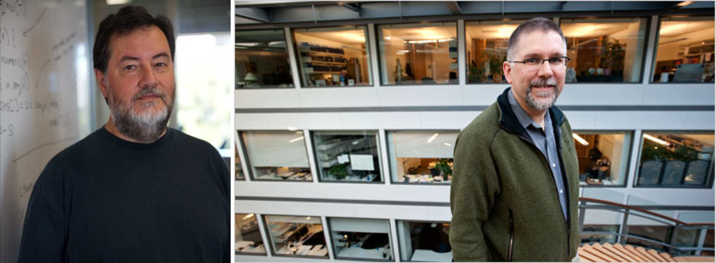

Ross Ihaka und Robert Gentleman

- *1992:* **Ross Ihaka und Robert Gentleman** (Universität Auckland) entwickeln eine freie Sprache eng orientiert an S: Geburtsstunde von **R**
- *1997:* Gründung des **R Development Core Team** und des **Comprehensive R Archive Network (CRAN)**
- *2000:* **R 1.0** und Übernahme des Klassen- und Objektmodells aus S4
- *2004/2013:* Weiterentwicklung von R: **R 2.0**, **R 3.0**
- *2015:* Gründung des **R-Consortium** (Microsoft, RStudio, HP, Google, Oracle etc.)
- Aktuelle Version: **R 3.2.3** “Wooden Christmas-Tree”

## Hilfefunktionen

#### Hilfe - Zu einer Funktion oder einem Paket

> ?…, ??… und help(…)

**Beschreibung**

Zeigt eine Beschreibung für Pakete, Funktionen und Datensätze an oder durchsucht die Beschreibungen aller installierter Pakete.

**Beispiel**

```r
## Zeige die Beschreibung für eine bestimmte Funktion,
## ein Paket oder einen Datensatz
help(plot)
?plot
?graphics::plot
?graphics

## Durchsuche alle Beschreibungen nach diesem Stichwort
??plot
```

#### Hilfe - Ich möchte mich in etwas einarbeiten

> vignette() und browseVignettes()

**Beschreibung**

Zeigt eine oder alle vorhandenen Einführungsdokumentationen (Vignettes) an.

**Beispiel**

```r
## Eine spezielle Vignette, deren Namen ich kenne, aufrufen
vignette(topic = "tidy-data", package = "tidyr")

## Zeige alle vorhandenen Vignettes
vignette()
browseVignettes()
```

## Quellen und Empfehlungen

#### Weblinks und Literatur

**Web**

- https://www.r-project.org/ - Homepage der R Foundation
- https://www.rstudio.com/ - Homepage von RStudio
- https://www.r-consortium.org/ - Homepage des R Consortium
- https://de.wikipedia.org/wiki/R_(Programmiersprache) - Deutscher Wiki-Artikel zu R (sehr gut!)
- https://de.wikibooks.org/wiki/GNU_R - Wikibook zur Einführung in R
- http://www.r-bloggers.com/how-slow-is-r-really/ - Einfacher Geschwindigkeitsvergleich

**Literatur**

- J. Adler, R in a nutshell, Second edition. (Sebastopol 2012)
- J. M. Chambers, A Statistical Data Language. In: R. C. Milton, J. A. Nelder (Hrsg.), Statistical Computation. (New York 1969), 179-199.
- J. M. Chambers, Object-Oriented Programming, Functional Programming and R. In: Statistical Science. 2/29, 2014, 167–180.
- K. Hornik, R FAQ (2015) - https://cran.r-project.org/doc/FAQ/R-FAQ.html